# Homework 1

## Question 1: Least squares and matrix calculations

```r
set.seed(43201)

n <- 100
p <- 5

X <- matrix(rnorm(n * p, mean = 0, sd = 1), nrow = n, ncol = p)
epsilon <- rnorm(n, mean = 0, sd = 0.7)

X <- cbind(1, X)
beta <- c(3, 1.4, -0.9, 0.7, 0, 1.1)
y <- as.vector(X %*% beta + epsilon)
```

### a

```r
rank_X <- qr(X)$rank
dim_X <- dim(X)
beta_hat <- lm(y ~ X - 1)$coefficients

c(rank_of_X = rank_X, dimension_of_X = dim_X)
```

```
      rank_of_X dimension_of_X1 dimension_of_X2
              6             100               6
```

```r
data.frame(
  coefficient = c("Intercept", paste0("x", 1:5)),
  assigned = beta,
  estimated = unname(beta_hat)
)
```

```
  coefficient assigned  estimated
1   Intercept      3.0  3.0063210
2          x1      1.4  1.4171604
3          x2     -0.9 -0.8883453
4          x3      0.7  0.7952834
5          x4      0.0  0.0484378
6          x5      1.1  1.1319341
```

The estimated coefficients are close to the values used to generate the data.

### b

```r
yhat <- X %*% beta_hat
resid <- y - yhat
RMSE <- sqrt(mean(resid^2))

RMSE
```

```
[1] 0.6763696
```

### c

```r
max(abs(t(X) %*% resid))
```

```
[1] 5.878631e-14
```

The value is small, indicating that the residuals are orthogonal to the columns of the design matrix.

## Question 2: Gaussian likelihood for linear regression

### a

The log-likelihood is

$$\ell(\boldsymbol{\beta},\sigma^2)
=-\frac{n}{2}\log(2\pi\sigma^2)
-\frac{1}{2\sigma^2}
(\mathbf{y}-\mathbf{X}\boldsymbol{\beta})^{\mathsf T}
(\mathbf{y}-\mathbf{X}\boldsymbol{\beta}).$$

Define the residual sum of squares by

$$\operatorname{RSS}(\boldsymbol{\beta})
=\left\lVert \mathbf{y}-\mathbf{X}\boldsymbol{\beta}\right\rVert_2^2
=(\mathbf{y}-\mathbf{X}\boldsymbol{\beta})^{\mathsf T}
(\mathbf{y}-\mathbf{X}\boldsymbol{\beta}).$$

Thus,

$$\ell(\boldsymbol{\beta},\sigma^2)
=-\frac{n}{2}\log(2\pi\sigma^2)
-\frac{1}{2\sigma^2}\operatorname{RSS}(\boldsymbol{\beta}).$$

For fixed $\sigma^2>0$, the first term is constant with respect to $\boldsymbol{\beta}$ and $-1/(2\sigma^2)<0$. Consequently,

$$\widehat{\boldsymbol{\beta}}_{\mathrm{MLE}}
=\underset{\boldsymbol{\beta}}{\arg\max}\,
\ell(\boldsymbol{\beta},\sigma^2)
=\underset{\boldsymbol{\beta}}{\arg\min}\,
\operatorname{RSS}(\boldsymbol{\beta})
=\widehat{\boldsymbol{\beta}}_{\mathrm{OLS}}.$$

### b

The log-likelihood is

$$\ell(\boldsymbol{\beta},\sigma^2)
=-\frac{n}{2}\log(2\pi\sigma^2)
-\frac{1}{2\sigma^2}
(\mathbf{y}-\mathbf{X}\boldsymbol{\beta})^{\mathsf T}
(\mathbf{y}-\mathbf{X}\boldsymbol{\beta}).$$

To find the MLE of $\sigma^2$, differentiate with respect to $\sigma^2$. For the first term,

$$\frac{\partial}{\partial\sigma^2}
\left[-\frac{n}{2}\log(2\pi\sigma^2)\right]
=-\frac{n}{2\sigma^2}.$$

For the second term, treat $(\mathbf{y}-\mathbf{X}\boldsymbol{\beta})^{\mathsf T} (\mathbf{y}-\mathbf{X}\boldsymbol{\beta})$ as constant with respect to $\sigma^2$:

$$\begin{aligned}
\frac{\partial}{\partial\sigma^2}
\left[-\frac{1}{2\sigma^2}
(\mathbf{y}-\mathbf{X}\boldsymbol{\beta})^{\mathsf T}
(\mathbf{y}-\mathbf{X}\boldsymbol{\beta})\right]
&=\frac{1}{2(\sigma^2)^2}
(\mathbf{y}-\mathbf{X}\boldsymbol{\beta})^{\mathsf T}
(\mathbf{y}-\mathbf{X}\boldsymbol{\beta}) \\
&=\frac{1}{2\sigma^4}
(\mathbf{y}-\mathbf{X}\boldsymbol{\beta})^{\mathsf T}
(\mathbf{y}-\mathbf{X}\boldsymbol{\beta}).
\end{aligned}$$

Combining the two derivatives and setting the result equal to zero gives

$$-\frac{n}{2\sigma^2}
+\frac{1}{2\sigma^4}
(\mathbf{y}-\mathbf{X}\boldsymbol{\beta})^{\mathsf T}
(\mathbf{y}-\mathbf{X}\boldsymbol{\beta})=0.$$

Multiplying both sides by $2\sigma^4$ and solving for $\sigma^2$,

$$-n\sigma^2
+(\mathbf{y}-\mathbf{X}\boldsymbol{\beta})^{\mathsf T}
(\mathbf{y}-\mathbf{X}\boldsymbol{\beta})=0,$$

so

$$\widehat{\sigma}_{\mathrm{MLE}}^2
=\frac{1}{n}
(\mathbf{y}-\mathbf{X}\widehat{\boldsymbol{\beta}})^{\mathsf T}
(\mathbf{y}-\mathbf{X}\widehat{\boldsymbol{\beta}}).$$

Therefore, the MLE of $\sigma$ is

$$\boxed{
\widehat{\sigma}_{\mathrm{MLE}}
=\sqrt{\frac{
(\mathbf{y}-\mathbf{X}\widehat{\boldsymbol{\beta}})^{\mathsf T}
(\mathbf{y}-\mathbf{X}\widehat{\boldsymbol{\beta}})}{n}}
}.$$

If $q=\operatorname{rank}(\mathbf{X})$ denotes the number of fitted coefficients (including the intercept), the unbiased estimator is

$$\widehat{\sigma}_{\mathrm{unb}}^2
=\frac{\operatorname{RSS}(\widehat{\boldsymbol{\beta}})}{n-q},$$

whereas the MLE divides by $n$. The denominators differ because estimating $q$ regression coefficients uses $q$ degrees of freedom. In this problem, $q=6$.

```r
mle_sigma2 <- sum(resid^2) / n
unbiased_sigma2 <- sum(resid^2) / (n - 6)

c(mle_sigma2, unbiased_sigma2)
```

```
[1] 0.4574759 0.4866765
```

The two estimators of $\sigma^2$ differ because MLE sigma is a biased estimator, while the unbiased estimator takes into account the degrees of freedom lost in estimating the regression coefficients.

### c

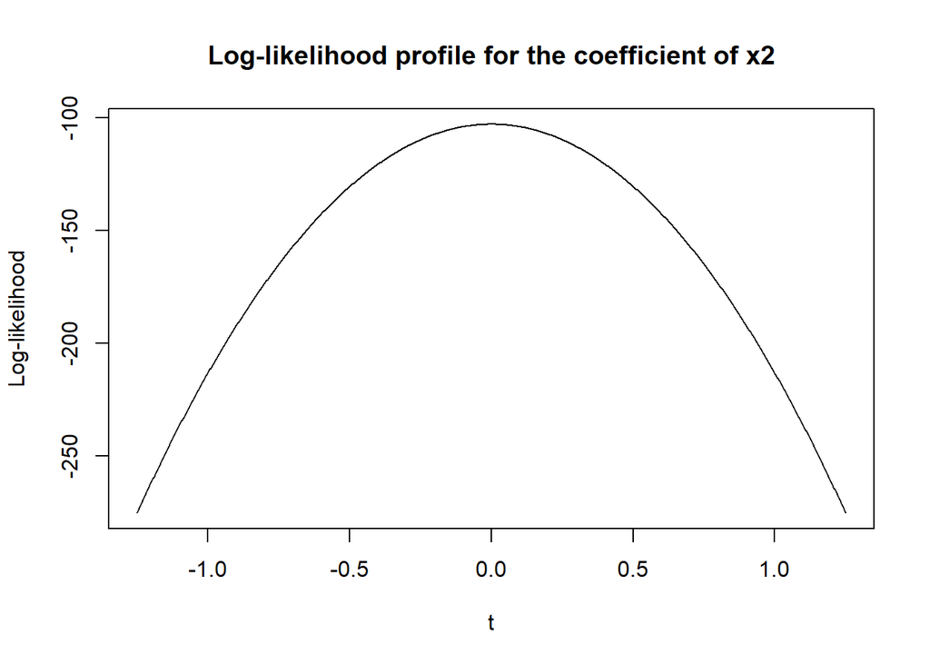

```r
ex2 <- c(0, 0, 1, 0, 0, 0)
t <- seq(-1.25, 1.25, length.out = 1000)
lik_betat_mlesig <- sapply(t, function(t) {
  beta_t <- beta_hat + t * ex2
  sigma2_t <- mle_sigma2
  loglik <- -n / 2 * log(2 * pi * sigma2_t) - sum((y - X %*% beta_t)^2) / (2 * sigma2_t)
  return(loglik)
})
plot(
  t,
  lik_betat_mlesig,
  type = "l",
  main = "Log-likelihood profile for the coefficient of x2",
  xlab = "t",
  ylab = "Log-likelihood"
)
```

The maximum occurs at $t=0$, for which $\boldsymbol{\beta}(0)=\widehat{\boldsymbol{\beta}}$. This agrees with the least-squares result because $\widehat{\boldsymbol{\beta}}$ minimizes the residual sum of squares.

More precisely, for any fixed $\sigma^2>0$, changing $\sigma^2$ rescales the term $-\operatorname{RSS}(\boldsymbol{\beta})/(2\sigma^2)$ but does not change its maximizer with respect to $\boldsymbol{\beta}$. Hence the maximizer remains $\widehat{\boldsymbol{\beta}}$.

## Question 3: Starting values in nonconvex optimization

### a

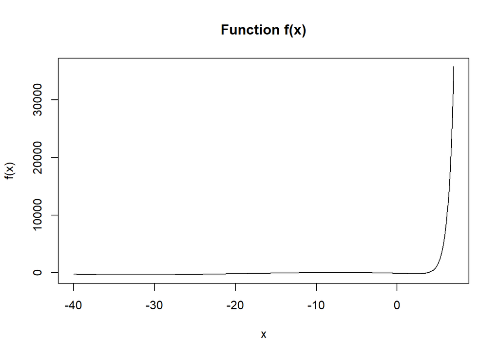

```r
x <- seq(-40, 7, length.out = 1000)
f <- function(x) exp(1.5 * x) - 3 * (x + 6)^2 - 0.05 * x^3
f_prime <- function(x) 1.5 * exp(1.5 * x) - 6 * (x + 6) - 0.15 * x^2
plot(x, f(x), type = "l", main = "Function f(x)", xlab = "x", ylab = "f(x)")
```

As the question called it a objective function, I assume it is a function to be maximized.

### b

```r
result_neg15 <- optim(
  par = -15,
  fn = f,
  gr = f_prime,
  method = "BFGS"
)
result_0 <- optim(
  par = 0,
  fn = f,
  gr = f_prime,
  method = "BFGS"
)

data.frame(
  starting_value = c(-15, 0),
  final_x = c(result_neg15$par, result_0$par),
  objective_value = c(result_neg15$value, result_0$value),
  absolute_gradient = c(
    abs(f_prime(result_neg15$par)),
    abs(f_prime(result_0$par))
  ),
  convergence_code = c(result_neg15$convergence, result_0$convergence)
)
```

```
  starting_value    final_x objective_value absolute_gradient convergence_code
1            -15 -32.649111       -390.3858      8.725087e-08                0
2              0   2.349967       -175.8626      6.556057e-07                0
```

### c

The initial values $x_0=-15$ and $x_0=0$ lead to different terminal points and different objective values $f(x)$. Although `optim()` reports convergence in both cases, the results show that BFGS converges to different stationary points depending on its initialization. Thus, for a nonconvex objective, one should use multiple starting values and compare the resulting objective values. Here, because $f(x)\to+\infty$ as $x\to+\infty$, no collection of finite local searches can identify a finite global maximizer on $\mathbb{R}$.

## Question 4: Nearly collinear predictors

```r
set.seed(43202)
u <- rnorm(n, mean = 0, sd = 1)
x6 <- X[,2] + 1e-4 * u

Xplus <- cbind(X, x6)
ystar <- y + 1e-3 * u
```

### a

```r
model_y_X <- lm(y ~ X - 1)
model_y_Xplus <- lm(y ~ Xplus - 1)

c(X = kappa(X), Xplus = kappa(Xplus))
```

```
           X        Xplus
    1.950478 31344.795552
```

```r
c(
  X = sqrt(mean((y - model_y_X$fitted.values)^2)),
  Xplus = sqrt(mean((y - model_y_Xplus$fitted.values)^2))
)
```

```
        X     Xplus
0.6763696 0.6754668
```

```r
c(
  x1 = unname(model_y_Xplus$coefficients[2]),
  x6 = unname(model_y_Xplus$coefficients[7])
)
```

```
       x1        x6
 351.6766 -350.2588
```

### b

```r
model_ystar_Xplus <- lm(ystar ~ Xplus - 1)

c(
  delta_x1 = unname(model_ystar_Xplus$coefficients[2] - model_y_Xplus$coefficients[2]),
  delta_x6 = unname(model_ystar_Xplus$coefficients[7] - model_y_Xplus$coefficients[7])
)
```

```
delta_x1 delta_x6
     -10       10
```

```r
c(
  RMSE_yhat_ystarhat = sqrt(mean((model_y_Xplus$fitted.values - model_ystar_Xplus$fitted.values)^2))
)
```

```
RMSE_yhat_ystarhat
       0.001015879
```

```r
c(
  Max_diff_yhat_ystarhat = max(abs(model_y_Xplus$fitted.values - model_ystar_Xplus$fitted.values))
)
```

```
Max_diff_yhat_ystarhat
           0.002572675
```

### c

Because $\mathbf{x}_6=\mathbf{x}_1+10^{-4}\mathbf{u}$, we have $10^{-3}\mathbf{u}=10(\mathbf{x}_6-\mathbf{x}_1)$. Therefore,

$$\begin{aligned}
\mathbf{y}^*
&=\mathbf{y}+10(\mathbf{x}_6-\mathbf{x}_1) \\
&=\beta_0\mathbf{1}_n+\mathbf{x}_1\beta_1
+\mathbf{x}_2\beta_2+\cdots+\mathbf{x}_6\beta_6
+\boldsymbol{\varepsilon}+10\mathbf{x}_6-10\mathbf{x}_1 \\
&=\beta_0\mathbf{1}_n+\mathbf{x}_1(\beta_1-10)
+\mathbf{x}_2\beta_2+\cdots
+\mathbf{x}_6(\beta_6+10)+\boldsymbol{\varepsilon}.
\end{aligned}$$

Thus, a perturbation of only $10^{-3}\mathbf{u}$ in the response shifts the two nearly aliased coefficients by approximately $-10$ and $+10$, respectively, while leaving the fitted values nearly unchanged. This illustrates the instability of individual coefficient estimates under severe multicollinearity.

The example suggests that even small perturbations in the response can lead to large changes in the estimated coefficients when dealing with nearly collinear predictors.

## Question 5: Data preparation and summary statistics

### a

```r
library(tidyverse)
Q5_df <- read_csv("data/data-manipulation.csv")
n_dim <- ncol(Q5_df)
col_types <- c("character", "factor", "numeric", "numeric", "numeric")
n_dup_id <- nrow(Q5_df) - nrow(distinct(Q5_df, observation_id))
n_NA <- apply(Q5_df, 2, function(x) sum(is.na(x)))
Analysis_table <- Q5_df %>%
  drop_na(response) %>%
  mutate(feature_sum = x1 + x2)

c("number of columns" = n_dim, "number of rows" = nrow(Q5_df), "duplicated identifiers" = n_dup_id)
```

```
     number of columns         number of rows duplicated identifiers
                     5                     24                      0
```

```r
setNames(col_types, names(Q5_df))
```

```
observation_id          group             x1             x2       response
   "character"       "factor"      "numeric"      "numeric"      "numeric"
```

```r
n_NA
```

```
observation_id          group             x1             x2       response
             0              0              0              0              3
```

### b

```r
Analysis_table %>%
  group_by(group) %>%
  summarize(
    case = n(),
    mean_response = mean(response),
    mean_feature_sum = mean(feature_sum)
  )
```

```
# A tibble: 3 x 4
  group  case mean_response mean_feature_sum
  <chr> <int>         <dbl>            <dbl>
1 A         7          5.6              3.6
2 B         7          7.60             4.93
3 C         7          8.00             6.59
```

```r
Max3_resp <- Analysis_table %>%
  arrange(desc(response)) %>%
  head(3) %>%
  select(-c(x1, x2))

Max3_resp
```

```
# A tibble: 3 x 4
  observation_id group response feature_sum
  <chr>          <chr>    <dbl>       <dbl>
1 obs-22         C         9.24         6.6
2 obs-16         B         9            5.2
3 obs-14         B         8.66         5
```

```r
nrow(Analysis_table) == sum(!is.na(Q5_df$response))
```

```
[1] TRUE
```

```r
print(paste0("The analysis table has ", sum(is.na(Analysis_table)), " NA's"))
```

```
[1] "The analysis table has 0 NA's"
```

```r
n_dup_id <- nrow(Analysis_table) - nrow(distinct(Analysis_table, observation_id))
print(paste0("There are ", n_dup_id, " duplicate IDs"))
```

```
[1] "There are 0 duplicate IDs"
```

## Question 6: Can 39 million Fitbit records represent US adults?

### a

No. The 39 million daily records are not independent observations. Each participant can contribute repeated daily measurements, so records from the same person are likely to be correlated. Measurements from participants in the same family may also be correlated because family members can share environments, routines, and health behaviors.

Participants may contribute different numbers of recorded days for several reasons. For example, people who walk more or place a higher value on their health may be more willing to buy a wearable device early, wear it consistently, and upload their records. BYOD participants may therefore have longer observation histories than participants who received a Fitbit through WEAR. Device nonuse, loss, technical problems, and differences in willingness to share data can also affect the number of recorded days.

Averaging all daily records gives participant $i$ weight proportional to the number of days they recorded, rather than giving every participant equal weight. Thus, a person with 1,000 recorded days contributes 100 times as much to the average as a person with 10 recorded days. If the number of contributed days is related to activity or health behavior, the resulting average can be biased for the target in which each US adult receives equal weight. The unequal composition of the two groups reinforces this concern: BYOD is about 1.4 times the size of WEAR and differs from WEAR in important demographic characteristics, so the pooled record-level average may reflect BYOD participants especially heavily.

### b

No. The difference in median daily steps does not show that already owning a Fitbit causes people to walk more. Because participants were not randomly assigned to own a Fitbit before entering the study, the comparison establishes at most an association between prior Fitbit ownership and daily steps.

A plausible alternative explanation is self-selection. People who already exercise regularly may be more motivated to purchase a Fitbit with their own money so that they can track their performance; these more active people would then enter the BYOD group. In contrast, WEAR participants received a Fitbit only if they did not already own one, so this group may include more people who had less interest in exercise or no established exercise routine. Therefore, pre-existing differences in motivation and activity could explain the higher median in the BYOD group even if owning a Fitbit itself had no causal effect on walking.

### c

Selection of participants can make this large dataset unrepresentative of US adults. As discussed above, belonging to BYOD or WEAR may reveal something about a participant’s pre-existing exercise habits, interest in health, or ability and willingness to use a wearable device. More generally, people who volunteer for the All of Us Research Program and agree to share Fitbit data may differ systematically from people who do not participate. The demographic differences between BYOD and WEAR further show that the observed sample is not homogeneous. Consequently, the participants need not resemble the US adult population whose mean is the target.

Selection of recorded days can introduce an additional difference. A day is observed only when a participant wears the device and successfully shares its data, and this may depend on the person’s activity, health, or routine on that day. Activity also varies over time. For example, records concentrated in cold winter periods could contain fewer outdoor steps than records spread evenly over the year. Conversely, participants might be especially likely to wear a Fitbit on active days. The direction of the resulting bias therefore cannot be determined without more information.

Finally, the naive average treats every recorded day equally rather than first computing each participant’s average and then giving each adult equal weight. It consequently overweights participants who contribute more days, while excluding nonparticipants entirely. Because both the people observed and the days recorded are selected, the average of all available daily step counts may fail to estimate the participant-weighted mean among all US adults, regardless of the dataset’s very large size.